# Introduction to *censCov*

## Methods

The following methods for censored covariates are implemented in `thlm`.

### Complete cases

When `method = "cc"`, `thlm` removes rows with `delta = 0` and fits the linear model via `lm`.

```r
> thlm(Y ~ Surv(X, delta) + Z, data = dat, method = "cc")
```

```
 Call: thlm(formula = Y ~ Surv(X, delta) + Z, data = dat, method = "cc")

 Hypothesis test of association
H0: a1 = 0, p-value = 0.1028
```

or

```r
> thlm(Y ~ X + Z, data = dat, subset = delta == 1)
```

```
 Call: thlm(formula = Y ~ X + Z, data = dat, subset = delta == 1)

 Hypothesis test of association
 H0: a1 = 0, p-value = 0.1047
```

The two $p$-values differs a bit because the `thlm` returns the Wald $p$-value.

### Reverse survival regression

```r
> summary(thlm(Y ~ Surv(X, delta) + Z, data = dat, method = "rev"))
```

```
Call:
thlm(formula = Y ~ Surv(X, delta) + Z, data = dat, method = "rev")

 Reverse survival regression

 Coefficients:
  Estimate   StdErr z.value p.value
Y -0.18333  0.10056  -1.823  0.0683 .
---
Signif. codes:  0 '***' 0.001 '**' 0.01 '*' 0.05 '.' 0.1 ' ' 1
```

### Deletion threshold regression

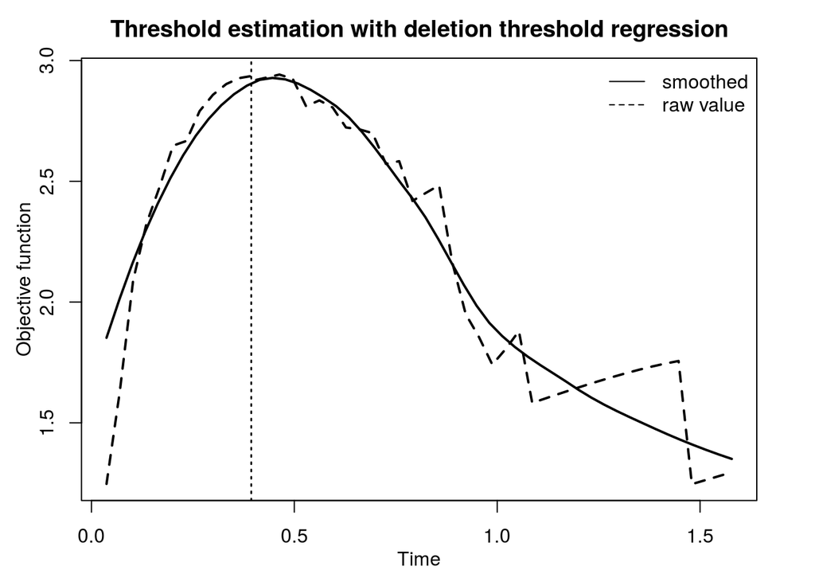

```
Call:
thlm(formula = Y ~ Surv(X, delta) + Z, data = dat, method = "del",
    B = 100)

 Deletion threshold regression
 Optimal threshold is 0.394

 Coefficients:
      Estimate    StdErr  z.value   p.value
a1:X  0.642742  0.235796   2.7258  0.006414 **
a2:Z -0.527387  0.039061 -13.5018 < 2.2e-16 ***
b1:X  0.307045  0.117716   2.6084  0.009098 **
---
Signif. codes:  0 '***' 0.001 '**' 0.01 '*' 0.05 '.' 0.1 ' ' 1

Under the assumption that X is independent of Z given X*. See ?thlm for more detail.
```

```r
> summary(thlm(Y ~ Surv(X, delta) + Z, data = dat, method = "del", B = 100))
```

### Complete threshold regression

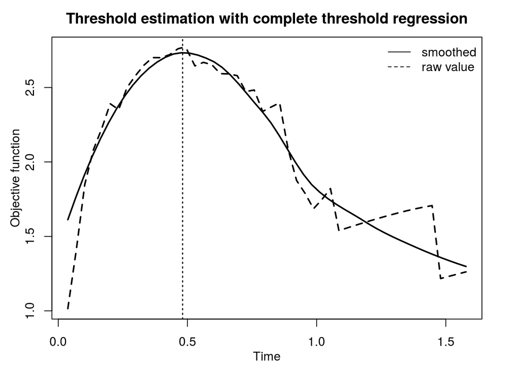

```
Call:
thlm(formula = Y ~ Surv(X, delta) + Z, data = dat, method = "com",
    B = 100)

 Complete threshold regression
 Optimal threshold is 0.481

 Coefficients:
      Estimate    StdErr  z.value p.value
a1:X  0.368099  0.304016   1.2108  0.2260
a2:Z -0.521533  0.036569 -14.2617  <2e-16 ***
b1:X  0.185574  0.138638   1.3386  0.1807
---
Signif. codes:  0 '***' 0.001 '**' 0.01 '*' 0.05 '.' 0.1 ' ' 1

Under the assumption that X is independent of Z given X*. See ?thlm for more detail.
```

```r
> summary(thlm(Y ~ Surv(X, delta) + Z, data = dat, method = "com", B = 100))
```

### All

The `thlm` function allows `method = "all"` that runs the complete cases analysis, reverse survival regression, deletion threshold regression, and complete threshold regression at once.

```r
> summary(thlm(Y ~ Surv(X, delta) + Z, data = dat, method = "all", B = 100,
+              control = list(t0.plot = FALSE)))
```

```
Call:
thlm(formula = Y ~ Surv(X, delta) + Z, data = dat, method = "all",
    B = 100, control = list(t0.plot = FALSE))

Complete-case regression

 Coefficients:
   Estimate    StdErr  z.value p.value
X  0.345912  0.212040   1.6314  0.1028
Z -0.526268  0.040216 -13.0861  <2e-16 ***
---
Signif. codes:  0 '***' 0.001 '**' 0.01 '*' 0.05 '.' 0.1 ' ' 1

Reverse survival regression

 Coefficients:
  Estimate   StdErr z.value p.value
Y -0.18333  0.10056  -1.823  0.0683 .
---
Signif. codes:  0 '***' 0.001 '**' 0.01 '*' 0.05 '.' 0.1 ' ' 1

Deletion threshold regression
 Optimal threshold is 0.394
 Coefficients:
      Estimate    StdErr  z.value   p.value
a1:X  0.642742  0.264088   2.4338  0.014941 *
a2:Z -0.527387  0.039061 -13.5018 < 2.2e-16 ***
b1:X  0.307045  0.117716   2.6084  0.009098 **
---
Signif. codes:  0 '***' 0.001 '**' 0.01 '*' 0.05 '.' 0.1 ' ' 1

Complete threshold regression
 Optimal threshold is 0.481
 Coefficients:
      Estimate    StdErr  z.value p.value
a1:X  0.368099  0.308850   1.1918  0.2333
a2:Z -0.521533  0.036569 -14.2617  <2e-16 ***
b1:X  0.185574  0.138638   1.3386  0.1807
---
Signif. codes:  0 '***' 0.001 '**' 0.01 '*' 0.05 '.' 0.1 ' ' 1

Under the assumption that X is independent of Z given X*. See ?thlm for more detail.
```

## FAQ

**Can `thlm` fit model with one censored covariate ($X$) without any fully observed covaraite ($Z$)?**

Yes. For example:

```r
> summary(thlm(Y ~ Surv(X, delta), data = dat, method = "all", B = 100,
+              control = list(t0.plot = FALSE)))
```

```
Call:
thlm(formula = Y ~ Surv(X, delta), data = dat, method = "all",
    B = 100, control = list(t0.plot = FALSE))

Complete-case regression

 Coefficients:
  Estimate  StdErr z.value p.value
X  0.10360 0.30109  0.3441  0.7308

Reverse survival regression

 Coefficients:
   Estimate    StdErr z.value p.value
Y -0.059851  0.076203 -0.7854  0.4322

Deletion threshold regression
 Optimal threshold is 0.394
 Coefficients:
     Estimate  StdErr z.value p.value
a1:X  0.49723 0.34765  1.4303  0.1526
b1:X  0.23753 0.16906  1.4051  0.1600

Complete threshold regression
 Optimal threshold is 0.481
 Coefficients:
     Estimate   StdErr z.value p.value
a1:X 0.082171 0.363501  0.2261  0.8212
b1:X 0.041426 0.196624  0.2107  0.8331

Under the assumption that X is independent of Z given X*. See ?thlm for more detail.
```

**Can `thlm` fit model with one censored covariate ($X$) and multiple fully observed covaraites ($Z$)?**

Yes. For example:

```r
> dat$Z2 <- dat$Z^2
> summary(thlm(Y ~ Surv(X, delta) + Z + Z2, data = dat, method = "all", B = 100,
+              control = list(t0.plot = FALSE)))
```

```
Call:
thlm(formula = Y ~ Surv(X, delta) + Z + Z2, data = dat, method = "all",
    B = 100, control = list(t0.plot = FALSE))

Complete-case regression

 Coefficients:
    Estimate    StdErr z.value  p.value
X   0.350485  0.212926  1.6460 0.099754 .
Z  -0.608191  0.216904 -2.8040 0.005048 **
Z2  0.011590  0.030151  0.3844 0.700687
---
Signif. codes:  0 '***' 0.001 '**' 0.01 '*' 0.05 '.' 0.1 ' ' 1

Reverse survival regression

 Coefficients:
  Estimate   StdErr z.value p.value
Y -0.18087  0.10079 -1.7946 0.07272 .
---
Signif. codes:  0 '***' 0.001 '**' 0.01 '*' 0.05 '.' 0.1 ' ' 1

Deletion threshold regression
 Optimal threshold is 0.394
 Coefficients:
       Estimate    StdErr z.value  p.value
a1:X   0.654823  0.253949  2.5786 0.009921 **
a2:Z  -0.623451  0.211023 -2.9544 0.003132 **
a3:Z2  0.013604  0.029366  0.4633 0.643169
b1:X   0.312817  0.118646  2.6366 0.008375 **
---
Signif. codes:  0 '***' 0.001 '**' 0.01 '*' 0.05 '.' 0.1 ' ' 1

Complete threshold regression
 Optimal threshold is 0.481
 Coefficients:
        Estimate     StdErr z.value  p.value
a1:X   0.3745097  0.2656319  1.4099 0.158575
a2:Z  -0.5685414  0.1997397 -2.8464 0.004422 **
a3:Z2  0.0066448  0.0277542  0.2394 0.810784
b1:X   0.1888058  0.1396247  1.3522 0.176299
---
Signif. codes:  0 '***' 0.001 '**' 0.01 '*' 0.05 '.' 0.1 ' ' 1

Under the assumption that X is independent of Z given X*. See ?thlm for more detail.
```

**Does the censored covariate ($X$) need to be specified first in the `formula`?**

Not nesscary. For exmaple:

```r
> dat$Z2 <- dat$Z^2
> summary(thlm(Y ~ Z + Surv(X, delta) + Z2, data = dat, method = "all", B = 100,
+              control = list(t0.plot = FALSE)))
```

```
Call:
thlm(formula = Y ~ Z + Surv(X, delta) + Z2, data = dat, method = "all",
    B = 100, control = list(t0.plot = FALSE))

Complete-case regression

 Coefficients:
    Estimate    StdErr z.value  p.value
X   0.350485  0.212926  1.6460 0.099754 .
Z  -0.608191  0.216904 -2.8040 0.005048 **
Z2  0.011590  0.030151  0.3844 0.700687
---
Signif. codes:  0 '***' 0.001 '**' 0.01 '*' 0.05 '.' 0.1 ' ' 1

Reverse survival regression

 Coefficients:
  Estimate   StdErr z.value p.value
Y -0.18087  0.10079 -1.7946 0.07272 .
---
Signif. codes:  0 '***' 0.001 '**' 0.01 '*' 0.05 '.' 0.1 ' ' 1

Deletion threshold regression
 Optimal threshold is 0.394
 Coefficients:
       Estimate    StdErr z.value  p.value
a1:X   0.654823  0.274355  2.3868 0.016997 *
a2:Z  -0.623451  0.211023 -2.9544 0.003132 **
a3:Z2  0.013604  0.029366  0.4633 0.643169
b1:X   0.312817  0.118646  2.6366 0.008375 **
---
Signif. codes:  0 '***' 0.001 '**' 0.01 '*' 0.05 '.' 0.1 ' ' 1

Complete threshold regression
 Optimal threshold is 0.481
 Coefficients:
        Estimate     StdErr z.value  p.value
a1:X   0.3745097  0.2989135  1.2529 0.210241
a2:Z  -0.5685414  0.1997397 -2.8464 0.004422 **
a3:Z2  0.0066448  0.0277542  0.2394 0.810784
b1:X   0.1888058  0.1396247  1.3522 0.176299
---
Signif. codes:  0 '***' 0.001 '**' 0.01 '*' 0.05 '.' 0.1 ' ' 1

Under the assumption that X is independent of Z given X*. See ?thlm for more detail.
```

**Can `thlm` fit model with more than one censored covariate ($X$)?**

No.

## Reference

Qian, Jing, Sy Han Chiou, Jacqueline E Maye, Folefac Atem, Keith A Johnson, and Rebecca A Betensky. 2018. “Threshold Regression to Accommodate a Censored Covariate.” *Biometrics* 74 (4). Wiley Online Library: 1261–70.